# Roll No: 213070010

## Problem Statement:

**Vowel F1, F2, F3**

**/u/ 300, 870, 2240**

We would like to use the DFT computed with various window lengths and shapes to estimate the vowel’s F0 and formant frequencies and study the obtained accuracies with reference to our ‘ground truth’ values. For the analysis, use a single waveform segment near the centre of your synthesized vowel. Plot the magnitude (dB) spectrum with rectangular and Hamming windows of lengths: 5 ms, 10 ms, 20 ms, 40 ms, each with a large zero-padded DFT. (i) Comment on the similarities and differences between the different computed spectra. (ii) Estimate the signal parameters from each of the magnitude spectra and report the error with respect to the ground-truth.

```python
%cd '/content/drive/MyDrive/Academics/Semester 1/Speech Processing/Assignment 2'
```

```
/content/drive/MyDrive/Academics/Semester 1/Speech Processing/Assignment 2
```

```python
import scipy
import numpy as np
import cmath
from scipy.io.wavfile import read,write
import matplotlib.pyplot as plt
```

```python
filename1 = '/content/drive/MyDrive/Academics/Semester 1/Speech Processing/Assignment 2/u_F0-120_F1-300F2-870F3-2240_B1-50B2B3-100_Fs16k.wav'
fs,data1 = read(filename1)
```

```python
filename2 = '/content/drive/MyDrive/Academics/Semester 1/Speech Processing/Assignment 2/u_F0-220_F1-300F2-870F3-2240_B1-50B2B3-100_Fs16k.wav'
fs,data2 = read(filename2)
```

```python
import IPython
IPython.display.Audio(filename1)
```

[interactive chart not shown]

```python
import IPython
IPython.display.Audio(filename2)
```

[interactive chart not shown]

## Computing DFT for different window lengths for different Audios:

## Helper function for computing STFT

```python
def stft(window_size, frame, signal, fs, window_type = "rectangular"):
  frame_ref = int(frame*fs)
  w_left = int(((window_size)/2)*fs)
  w_right = w_left
  segment = signal[frame_ref-w_left:frame_ref+w_right]

  if window_type == "rectangular":
    segment = segment
  elif window_type == "hamming":
    segment = np.hamming(len(segment))*segment
  else:
    err_string = window_type + " not defined"
    raise AttributeError(err_string)



  # Padding the sequence (Considering a padded sequence of 1024 samples)
  padded_sequence = np.zeros((1024))
  padded_sequence[0:len(segment)] = segment

  # Using fft to compure the dft of the sequence

  dft = np.fft.fft(padded_sequence)
  return dft
```

## For Audio with $F_{0} = 120$

```python
# general parameters

# Display range
fd = 5000
data = data1
```

### a) 5ms

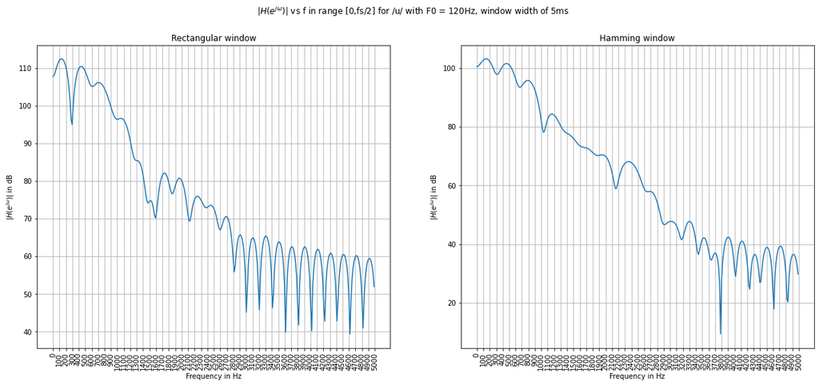

```python
stft_5ms_rect = stft(5*1e-3,0.25,data,16000) # STFT for the rectangular window
stft_5ms_hamm = stft(5*1e-3,0.25,data,16000, "hamming")
f = np.linspace(0,fs,1024)

mag_5ms_rect = list(map(abs,stft_5ms_rect))
db_mag_5ms_rect= 20*np.log10(mag_5ms_rect)

mag_5ms_hamm = list(map(abs,stft_5ms_hamm))
db_mag_5ms_hamm= 20*np.log10(mag_5ms_hamm)

# Plotting in range 0-Fs/2
fig = plt.figure(figsize = (20,8))
fig.suptitle("$|H(e^{j\omega})|$ vs f in range [0,fs/2] for /u/ with F0 = 120Hz, window width of 5ms")


# Getting the number of samples for display
range_f  = int(1024*(fd/fs))


# Subplot for Rectangular Window
plt.subplot(1,2,1)
plt.title("Rectangular window")
plt.plot(f[0:range_f],db_mag_5ms_rect[0:range_f])
plt.grid()
plt.xlabel("Frequency in Hz")
plt.xticks(np.arange(0,5100,100), rotation='vertical')
plt.ylabel("$|H(e^{j\omega})|$ in dB")

# Subplot for Hamming Window
plt.subplot(1,2,2)
plt.title("Hamming window")
plt.plot(f[0:range_f],db_mag_5ms_hamm[0:range_f])
plt.grid()
plt.xlabel("Frequency in Hz")
plt.xticks(np.arange(0,5100,100), rotation='vertical')
plt.ylabel("$|H(e^{j\omega})|$ in dB")
```

### Similarities

- Resolution in Frequency domain is not very high for both
- The magnitude of the spectrum tends to follow a decreasing pattern as we move towards higher frequencies.
- The estimated fundamental frequency is same
- Central lobe tends to repeat for both the signals at the same place

### Differences

- Higher sidelobe attenuation is reflected in rectangular window, just after the first formant frequency. Thus there is a drop in the magnitude spectrum. Sidelobe attenuation is comparatively lesser in Hamming window
- Lobe width is more for Hamming window
- Hamming window seems to estimate the envelope better.

### Estimating Parameters:

| Parameters (Hz) | Rectangular | Hamming |
| --- | --- | --- |
| $F_{0}$ | 333 | 333 |
| $F_{1}$ | 150 | 250 |
| $F_{2}$ | 450 | 450 |
| $F_{3}$ | 1750 | 1750 |

### Error:

Error is being calculated as : Actual - Estimated

[output not shown]

### Observations

This is the wideband analysis since the width of the window is smaller. This is helpful is estimating where the sound changes in time domain but hard to infer acoustic properties in frequency domain better. We can neither infer the formant frequencies well not the pitch of thes sound. As we can see from the graph above that we have obtained a very high error while estimating the fundamental frequency and other formant frequency parameters.

### b) 10m

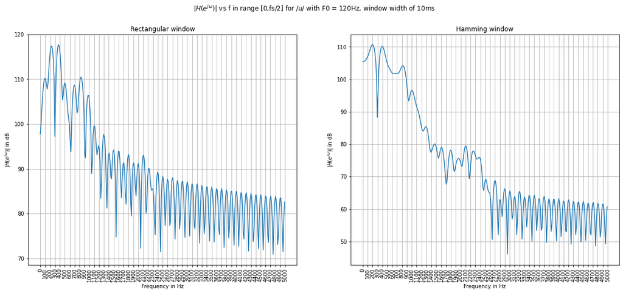

```python
stft_10ms_rect = stft(10*1e-3,0.25,data,16000)
stft_10ms_hamm = stft(10*1e-3,0.25,data,16000, "hamming")
f = np.linspace(0,fs,1024)

mag_10ms_rect = list(map(abs,stft_10ms_rect))
db_mag_10ms_rect= 20*np.log10(mag_10ms_rect)

mag_10ms_hamm = list(map(abs,stft_10ms_hamm))
db_mag_10ms_hamm= 20*np.log10(mag_10ms_hamm)

# Plotting in range 0-Fs/2
fig = plt.figure(figsize = (20,8))
fig.suptitle("$|H(e^{j\omega})|$ vs f in range [0,fs/2] for /u/ with F0 = 120Hz, window width of 10ms")


# Getting the number of samples for display
range_f  = int(1024*(fd/fs))


# Subplot for Rectangular Window
plt.subplot(1,2,1)
plt.title("Rectangular window")
plt.plot(f[0:range_f],db_mag_10ms_rect[0:range_f])
plt.grid()
plt.xlabel("Frequency in Hz")
plt.xticks(np.arange(0,5100,100), rotation='vertical')
plt.ylabel("$|H(e^{j\omega})|$ in dB")

# Subplot for Hamming Window
plt.subplot(1,2,2)
plt.title("Hamming window")
plt.plot(f[0:range_f],db_mag_10ms_hamm[0:range_f])
plt.grid()
plt.xlabel("Frequency in Hz")
plt.xticks(np.arange(0,5100,100), rotation='vertical')
plt.ylabel("$|H(e^{j\omega})|$ in dB")
```

### Similarities

- Both graphs are estimating the same formant frequencies.
- Better estimation of the fundamental frequency by both.
- Both window spectrums are able to highlight the formant frequencies much better than before.

### Differences

- The hamming window has a larger lobe width, thus with better frequency domain resolution it is able to estimate the formant locations much better than rectangular window.
- The sidelobe attenuation is more highlighted in the rectangular window analyis than hamming window.

### Estimating Parameters:

| Parameters | Rectangular | Hamming |
| --- | --- | --- |
| $F_{0}$ | ~200 | ~250 |
| $F_{1}$ | ~220 | ~210 |
| $F_{2}$ | ~890 | ~890 |
| $F_{3}$ | ~2180 | ~2180 |

### Error:

[output not shown]

### Observations

The analysis is still wideband, although the better resolution in frequency domain is now enabling us to estimate the higher formant frequencies much better as we can see from the graph, and the lower error rate. Also, the error in estimating the fundamental frquency is reduced as wel have more resolution in the frequency domain.

### c) 20ms

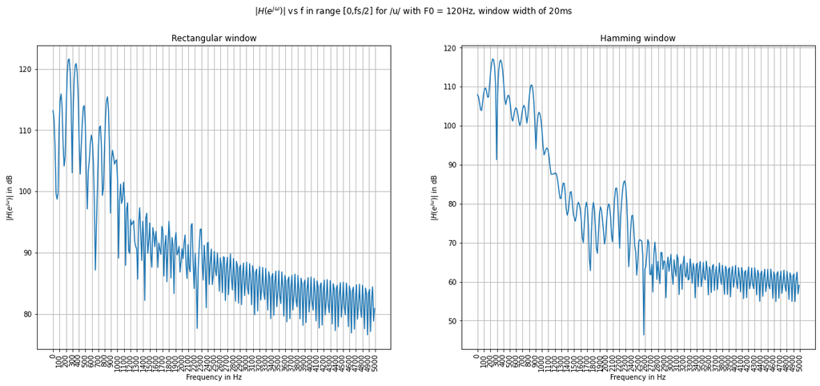

```python
stft_20ms_rect = stft(20*1e-3,0.25,data,16000)
stft_20ms_hamm = stft(20*1e-3,0.25,data,16000, "hamming")
f = np.linspace(0,fs,1024)

mag_20ms_rect = list(map(abs,stft_20ms_rect))
db_mag_20ms_rect= 20*np.log10(mag_20ms_rect)

mag_20ms_hamm = list(map(abs,stft_20ms_hamm))
db_mag_20ms_hamm= 20*np.log10(mag_20ms_hamm)

# Plotting in range 0-Fs/2
fig = plt.figure(figsize = (20,8))
fig.suptitle("$|H(e^{j\omega})|$ vs f in range [0,fs/2] for /u/ with F0 = 120Hz, window width of 20ms")

# Getting the number of samples for display
range_f  = int(1024*(fd/fs))

# Subplot for Rectangular Window
plt.subplot(1,2,1)
plt.title("Rectangular window")
plt.plot(f[0:range_f],db_mag_20ms_rect[0:range_f])
plt.grid()
plt.xlabel("Frequency in Hz")
plt.xticks(np.arange(0,5100,100), rotation='vertical')
plt.ylabel("$|H(e^{j\omega})|$ in dB")

# Subplot for Hamming Window
plt.subplot(1,2,2)
plt.title("Hamming window")
plt.plot(f[0:range_f],db_mag_20ms_hamm[0:range_f])
plt.grid()
plt.xlabel("Frequency in Hz")
plt.xticks(np.arange(0,5100,100), rotation='vertical')
plt.ylabel("$|H(e^{j\omega})|$ in dB")
```

### Similarities

- Spectrum gets noisy in the high frequency range.
- The magnitude of the spectrum tends to follow a decreasing pattern as we move towards higher frequencies.
- Peaks corresponding to distinct frequencies and their harmonics are better visible
- Envelope of the spectrum for both the rectangular and hamming window is easier of visualize.
- reduction in lobe width.

### Differences

- Effect of sidelobe attenuation in rectangular window is not that prominent in hamming window.
- The change is the spectrum is more gradual in hamming window than in rectangular window.

### Estimating Parameters:

| Parameters | Rectangular | Hamming |
| --- | --- | --- |
| $F_{0}$ | 250 | 250 |
| $F_{1}$ | 210 | 210 |
| $F_{2}$ | 850 | 860 |
| $F_{3}$ | 2190 | 2200 |

### Error:

[output not shown]

### d) 40ms

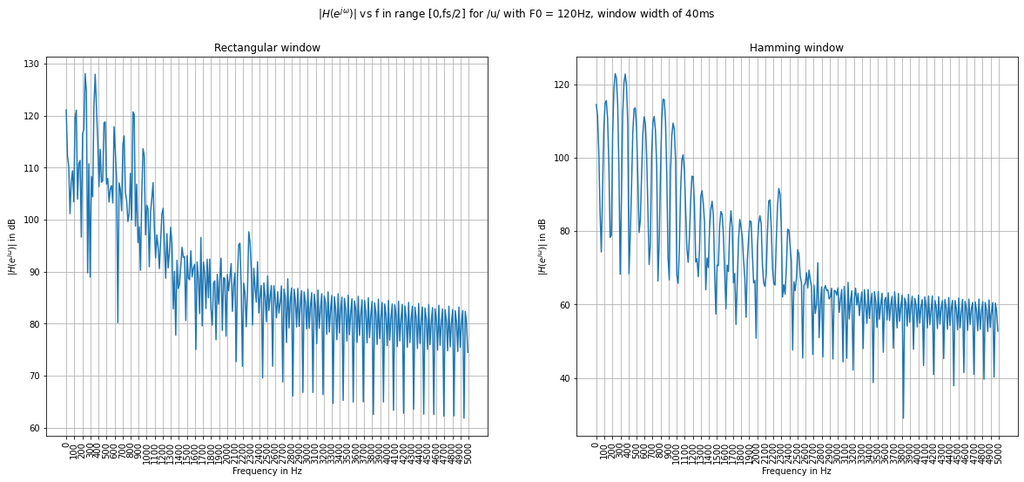

```python
stft_40ms_rect = stft(40*1e-3,0.25,data1,16000)
stft_40ms_hamm = stft(40*1e-3,0.25,data1,16000, "hamming")
f = np.linspace(0,fs,1024)

mag_40ms_rect = list(map(abs,stft_40ms_rect))
db_mag_40ms_rect= 20*np.log10(mag_40ms_rect)

mag_40ms_hamm = list(map(abs,stft_40ms_hamm))
db_mag_40ms_hamm= 20*np.log10(mag_40ms_hamm)

# Plotting in range 0-Fs/2
fig = plt.figure(figsize = (20,8))
fig.suptitle("$|H(e^{j\omega})|$ vs f in range [0,fs/2] for /u/ with F0 = 120Hz, window width of 40ms")


# Getting the number of samples for display
range_f  = int(1024*(fd/fs))


# Subplot for Rectangular Window
plt.subplot(1,2,1)
plt.title("Rectangular window")
plt.plot(f[0:range_f],db_mag_40ms_rect[0:range_f])
plt.grid()
plt.xlabel("Frequency in Hz")
plt.xticks(np.arange(0,5100,100), rotation='vertical')
plt.ylabel("$|H(e^{j\omega})|$ in dB")


# Subplot for Hamming Window
plt.subplot(1,2,2)
plt.title("Hamming window")
plt.plot(f[0:range_f],db_mag_40ms_hamm[0:range_f])
plt.grid()
plt.xlabel("Frequency in Hz")
plt.xticks(np.arange(0,5100,100), rotation='vertical')
plt.ylabel("$|H(e^{j\omega})|$ in dB")
```

### Similarities

- The magnitude of the spectrum tends to follow a decreasing pattern as we move towards higher frequencies.
- Spectrum is highly noisy, due to higher number of peaks
- Difficult to distinguish between peaks and non-peaks
- The envelope still followed the same trajectory in both the graphs.

### Differences

- Easier to estimate the formant in hamming compared to rectangular.
- The central lobe width in hamming is wider than that in the rectangualr window, distinction is clearly visible here.
- Rest the difference are similar as we have discussed in previous parts.

### Estimating Parameters:

| Parameters | Rectangular | Hamming |
| --- | --- | --- |
| $F_{0}$ | 125 | 125 |
| $F_{1}$ | 250 | 250 |
| $F_{2}$ | 820 | 820 |
| $F_{3}$ | 2250 | 2250 |

### Error:

| Parameters | Ground Truth | Error with Rectangular | Error with Hamming |
| --- | --- | --- | --- |
| $F_{0}$ | 120 | -5 | -5 |
| $F_{1}$ | 300 | 50 | 50 |
| $F_{2}$ | 870 | 50 | 50 |
| $F_{3}$ | 2240 | -10 | -10 |

### Observations

Now our window size has become large enough to be considered into the narrowband range. This gives a higher frequency resolution, thus we are able to count the peaks more clearly in a given range and estimate the pitch from the spectrum. However, the clarity on the formant frequencies has reduced due to similar peaks appearing in the neighbourhood. Still, the region where the formant frquencies might be located is more clear. These observations can be seen in the graph, and also be inferred from the error rate in estimating the parameters.

## For Audio with $F_{0} = 220$

```python
# general parameters

# Display range
fd = 5000

# Audio to use
data = data2
```

### a) 5ms

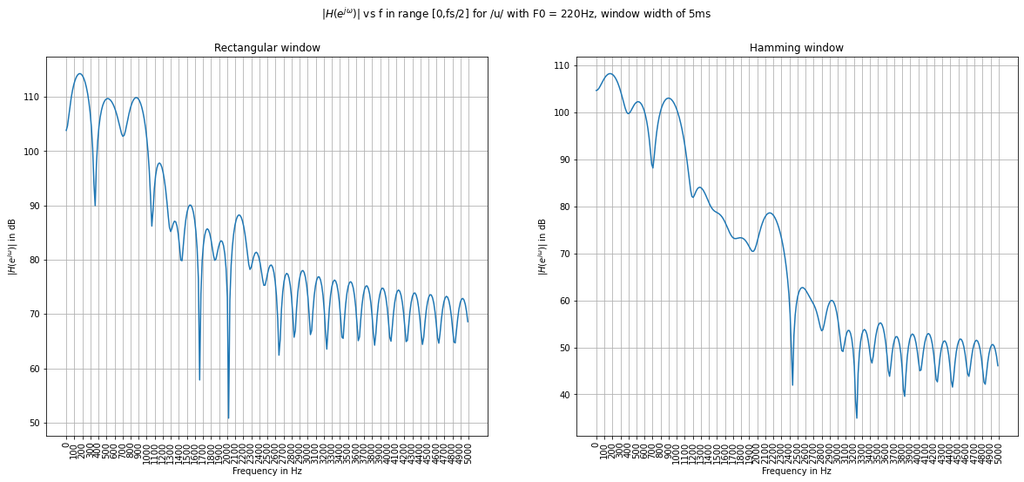

```python
stft_5ms_rect = stft(5*1e-3,0.25,data,16000)
stft_5ms_hamm = stft(5*1e-3,0.25,data,16000, "hamming")
f = np.linspace(0,fs,1024)

mag_5ms_rect = list(map(abs,stft_5ms_rect))
db_mag_5ms_rect= 20*np.log10(mag_5ms_rect)

mag_5ms_hamm = list(map(abs,stft_5ms_hamm))
db_mag_5ms_hamm= 20*np.log10(mag_5ms_hamm)

# Plotting in range 0-Fs/2
fig = plt.figure(figsize = (20,8))
fig.suptitle("$|H(e^{j\omega})|$ vs f in range [0,fs/2] for /u/ with F0 = 220Hz, window width of 5ms")


# Getting the number of samples for display
range_f  = int(1024*(fd/fs))


# Subplot for Rectangular Window
plt.subplot(1,2,1)
plt.title("Rectangular window")
plt.plot(f[0:range_f],db_mag_5ms_rect[0:range_f])
plt.grid()
plt.xlabel("Frequency in Hz")
plt.xticks(np.arange(0,5100,100), rotation='vertical')
plt.ylabel("$|H(e^{j\omega})|$ in dB")

# Subplot for Hamming Window
plt.subplot(1,2,2)
plt.title("Hamming window")
plt.plot(f[0:range_f],db_mag_5ms_hamm[0:range_f])
plt.grid()
plt.xlabel("Frequency in Hz")
plt.xticks(np.arange(0,5100,100), rotation='vertical')
plt.ylabel("$|H(e^{j\omega})|$ in dB")
```

### Similarities

- The formant frequencies are more or less similar to the ones we observed with 120 Hz signal frequency spectrum
- The lobes indicating the impulses are fairly visible.
- The magnitude of the spectrum tends to follow a decreasing pattern as we move towards higher frequencies.
- Higher error in estimating the fundamental frequency

### Differences

- In the range 1100 Hz to 1600 Hz, there is better resolution in the rectangular window spectrum but not in the hamming window spectrum.
- The attenuation after every peak is higher in the rectangular window, then in the hamming window.

### Estimating Parameters:

| Parameters | Rectangular | Hamming |
| --- | --- | --- |
| $F_{0}$ | 333 | 333 |
| $F_{1}$ | 150 | 200 |
| $F_{2}$ | 500 | 900 |
| $F_{3}$ | 2100 | 2100 |

### Error:

[output not shown]

### b) 10ms

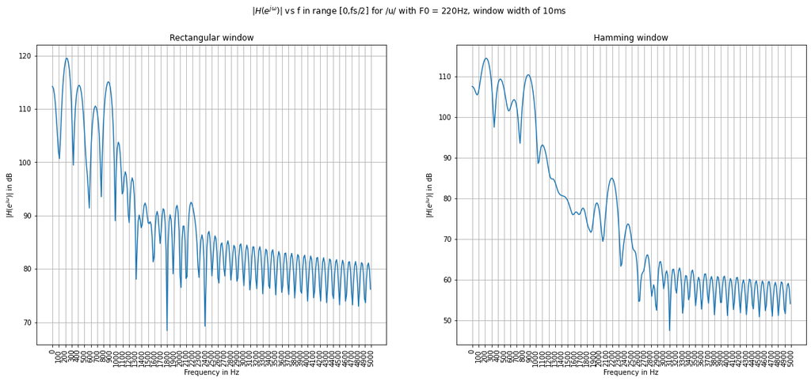

```python
stft_10ms_rect = stft(10*1e-3,0.25,data,16000)
stft_10ms_hamm = stft(10*1e-3,0.25,data,16000, "hamming")
f = np.linspace(0,fs,1024)

mag_10ms_rect = list(map(abs,stft_10ms_rect))
db_mag_10ms_rect= 20*np.log10(mag_10ms_rect)

mag_10ms_hamm = list(map(abs,stft_10ms_hamm))
db_mag_10ms_hamm= 20*np.log10(mag_10ms_hamm)

# Plotting in range 0-Fs/2
fig = plt.figure(figsize = (20,8))
fig.suptitle("$|H(e^{j\omega})|$ vs f in range [0,fs/2] for /u/ with F0 = 220Hz, window width of 10ms")


# Getting the number of samples for display
range_f  = int(1024*(fd/fs))


# Subplot for Rectangular Window
plt.subplot(1,2,1)
plt.title("Rectangular window")
plt.plot(f[0:range_f],db_mag_10ms_rect[0:range_f])
plt.grid()
plt.xlabel("Frequency in Hz")
plt.xticks(np.arange(0,5100,100), rotation='vertical')
plt.ylabel("$|H(e^{j\omega})|$ in dB")

# Subplot for Hamming Window
plt.subplot(1,2,2)
plt.title("Hamming window")
plt.plot(f[0:range_f],db_mag_10ms_hamm[0:range_f])
plt.grid()
plt.xlabel("Frequency in Hz")
plt.xticks(np.arange(0,5100,100), rotation='vertical')
plt.ylabel("$|H(e^{j\omega})|$ in dB")
```

### Similarities

- Peaks are more distinctly visible than the previous plots.
- The magnitude spectrum follows a downward trend in terms of magnitude.

### Differences

- Lobes are more distinctly visible in the rectangular window, then compared to the hamming window.
- The variations are higher in rectangular window than compared to hamming window.

### Estimating Parameters:

| Parameters | Rectangular | Hamming |
| --- | --- | --- |
| $F_{0}$ | 250 | 250 |
| $F_{1}$ | 210 | 200 |
| $F_{2}$ | 860 | 900 |
| $F_{3}$ | 2150 | 2200 |

### Error:

| Parameters | Ground Truth | Error with Rectangular | Error with Hamming |
| --- | --- | --- | --- |
| $F_{0}$ | 220 | -30 | -30 |
| $F_{1}$ | 300 | 90 | 100 |
| $F_{2}$ | 870 | 10 | -30 |
| $F_{3}$ | 2240 | 90 | 40 |

### Observations

As discussed in the earlier analysis with the 120 Hz signal, the analysis is midway between wideband and narrowband spectrum. We see a better resolution in the frequency domain as compared to the previous plots. We also see a reduction in error rate in estimating the fundamental frequency as well as the forman frquencies.

### c) 20ms

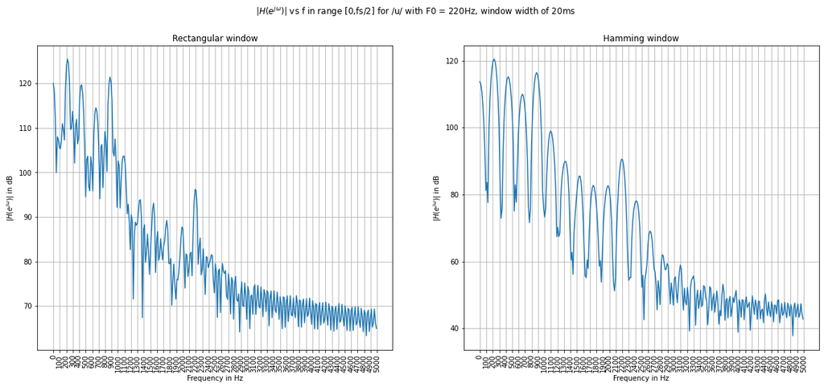

```python
stft_20ms_rect = stft(20*1e-3,0.25,data,16000)
stft_20ms_hamm = stft(20*1e-3,0.25,data,16000, "hamming")
f = np.linspace(0,fs,1024)

mag_20ms_rect = list(map(abs,stft_20ms_rect))
db_mag_20ms_rect= 20*np.log10(mag_20ms_rect)

mag_20ms_hamm = list(map(abs,stft_20ms_hamm))
db_mag_20ms_hamm= 20*np.log10(mag_20ms_hamm)

# Plotting in range 0-Fs/2
fig = plt.figure(figsize = (20,8))
fig.suptitle("$|H(e^{j\omega})|$ vs f in range [0,fs/2] for /u/ with F0 = 220Hz, window width of 20ms")

# Getting the number of samples for display
range_f  = int(1024*(fd/fs))

# Subplot for Rectangular Window
plt.subplot(1,2,1)
plt.title("Rectangular window")
plt.plot(f[0:range_f],db_mag_20ms_rect[0:range_f])
plt.grid()
plt.xlabel("Frequency in Hz")
plt.xticks(np.arange(0,5100,100), rotation='vertical')
plt.ylabel("$|H(e^{j\omega})|$ in dB")

# Subplot for Hamming Window
plt.subplot(1,2,2)
plt.title("Hamming window")
plt.plot(f[0:range_f],db_mag_20ms_hamm[0:range_f])
plt.grid()
plt.xlabel("Frequency in Hz")
plt.xticks(np.arange(0,5100,100), rotation='vertical')
plt.ylabel("$|H(e^{j\omega})|$ in dB")
```

### Similarities

- The spectrum has become more noisy than before with higher number of peaks. *The envelope is easier to visualize due to higher resolution in the frequency domain.

### Differences

- The peaks of the central lobe in the lower frequency region are more distincly visible in the hamming window than in the rectangular window due to lower sidelobe attenuation.

### Estimating Parameters:

| Parameters | Rectangular | Hamming |
| --- | --- | --- |
| $F_{0}$ | 250 | 250 |
| $F_{1}$ | 200 | 220 |
| $F_{2}$ | 890 | 890 |
| $F_{3}$ | 2200 | 2200 |

### Error:

[output not shown]

### d) 40ms

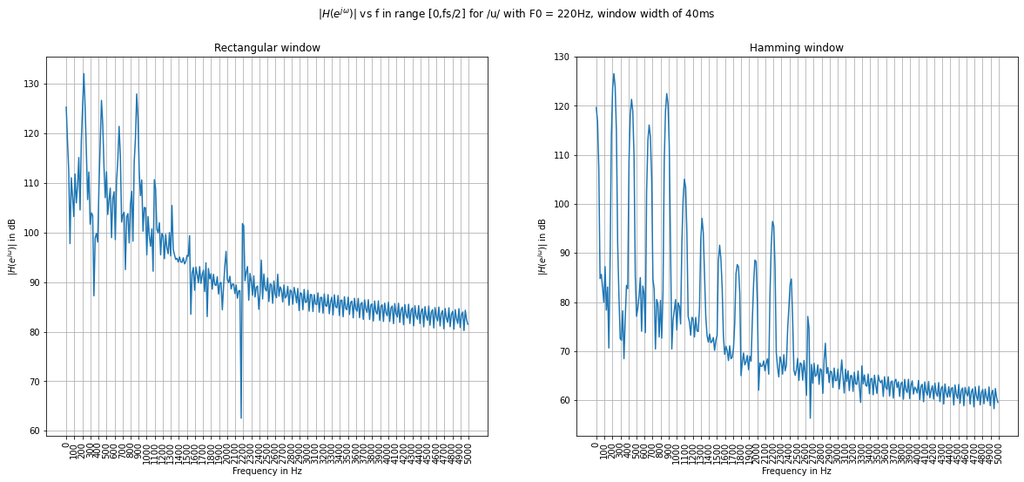

```python
stft_40ms_rect = stft(40*1e-3,0.25,data,16000)
stft_40ms_hamm = stft(40*1e-3,0.25,data,16000, "hamming")
f = np.linspace(0,fs,1024)

mag_40ms_rect = list(map(abs,stft_40ms_rect))
db_mag_40ms_rect= 20*np.log10(mag_40ms_rect)

mag_40ms_hamm = list(map(abs,stft_40ms_hamm))
db_mag_40ms_hamm= 20*np.log10(mag_40ms_hamm)

# Plotting in range 0-Fs/2
fig = plt.figure(figsize = (20,8))
fig.suptitle("$|H(e^{j\omega})|$ vs f in range [0,fs/2] for /u/ with F0 = 220Hz, window width of 40ms")


# Getting the number of samples for display
range_f  = int(1024*(fd/fs))


# Subplot for Rectangular Window
plt.subplot(1,2,1)
plt.title("Rectangular window")
plt.plot(f[0:range_f],db_mag_40ms_rect[0:range_f])
plt.grid()
plt.xlabel("Frequency in Hz")
plt.xticks(np.arange(0,5100,100), rotation='vertical')
plt.ylabel("$|H(e^{j\omega})|$ in dB")


# Subplot for Hamming Window
plt.subplot(1,2,2)
plt.title("Hamming window")
plt.plot(f[0:range_f],db_mag_40ms_hamm[0:range_f])
plt.grid()
plt.xlabel("Frequency in Hz")
plt.xticks(np.arange(0,5100,100), rotation='vertical')
plt.ylabel("$|H(e^{j\omega})|$ in dB")
```

### Similarities

- Spectrum is altogether noisy with higher number of central lobe peaks in the spectrum
- The magnitude follows a downward trend.
- The peaks have become sharped and the width of the central lobe has decreased.
- Position on impulses is getting more clearer.

### Differences

- Variation in the rectangular window spectrum is much higher than that of the hamming window spectrum. *Peaks are clearly visible in hamming window but not in rectangular window.*Sidelobe contribuition is clearly visible in the rectangular window, less prominent in hamming window.

### Estimating Parameters:

| Parameters | Rectangular | Hamming |
| --- | --- | --- |
| $F_{0}$ | 250 | 250 |
| $F_{1}$ | 200 | 220 |
| $F_{2}$ | 890 | 890 |
| $F_{3}$ | 2190 | 2190 |

### Error:

[output not shown]

### Observations

The spectrum has become narrowband. The lobe of the central width has decreased and their heights have incereased. The error in estimating the formants have incresed while not much changes has been observed in estimating the pitch.

```python
%cd '/content/drive/MyDrive/Academics/Semester 1/Speech Processing/Assignment 2'
```

```
/content/drive/MyDrive/Academics/Semester 1/Speech Processing/Assignment 2
```

```python
!jupyter nbconvert --to html '/content/drive/MyDrive/Academics/Semester 1/Speech Processing/Assignment 2/Speech_Processing:Assignment 1B.ipynb'
```

[output not shown]

[output cut: 75 more lines]

[output not shown]